# FPL Week 01 Analytics

Faiz MK

August 25, 2018

## Best Player You Can Get

What’s the best 15 players you can assemble, restrospectively speaking. This is if we take the maximum event_points of week02 with constraints given (15 players, 1000 cost).

```
##      web_name in_dreamteam event_points ict_index element_type
## 1   Etheridge         TRUE           16      10.5          GKP
## 2  Steve Cook         TRUE           14      13.9          DEF
## 3      Alonso         TRUE           13      18.5          DEF
## 4     Pereira        FALSE           12      12.7          DEF
## 5    Trippier        FALSE           11      12.0          DEF
## 6     Walcott        FALSE           13      12.1          MID
## 7  Mkhitaryan        FALSE           12      22.7          MID
## 8      Milner         TRUE           11      17.9          MID
## 9        Groß        FALSE           10      11.4          MID
## 10     Agüero         TRUE           20      31.1          FWD
## 11     Deeney        FALSE           12      19.2          FWD
## 12   Dubravka        FALSE            6       3.3          GKP
## 13      Mendy         TRUE            8      21.3          DEF
## 14       Mané         TRUE           10      32.0          MID
## 15 Arnautovic        FALSE            8      15.8          FWD
```

## Stats on Team Strength

Can we finetune the starting 11 to maximise chance of getting more points based on their opponent team strength for the week. This analysis look into current week’s result of total points gained by individual player, grouped by its opponent team strength as well as its own team strength

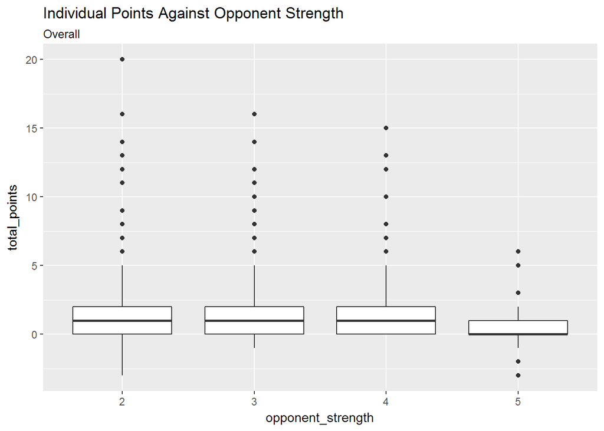

```r
library(ggplot2)
df_history$opponent_strength = as.factor(df_history$opponent_strength)
df_history$team_strength     = as.factor(df_history$team_strength)
p = ggplot(df_history) +
  geom_boxplot(aes(x=opponent_strength, y=total_points)) +
  ggtitle("Individual Points Against Opponent Strength", subtitle = "Overall")
print(p)
```

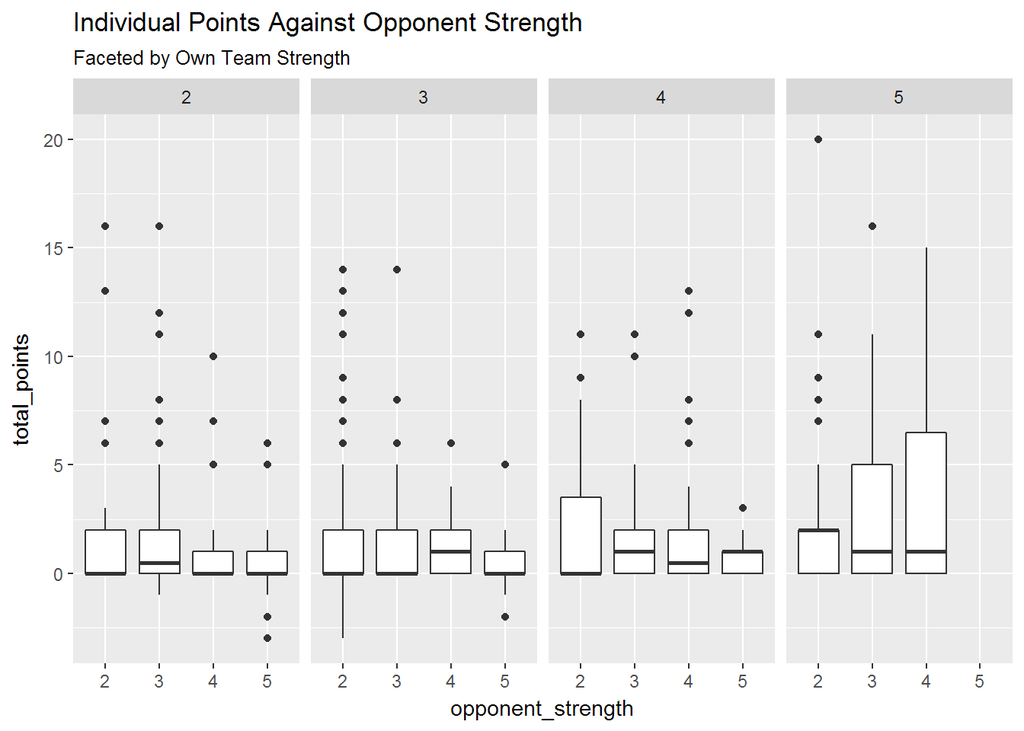

```r
## Now let's see if we breakdown by own team strength. Apparently, if the player in a stronger team,
## there's an increased chance of you getting higher points
p = p + facet_grid(. ~ team_strength) +
  ggtitle("Individual Points Against Opponent Strength", subtitle = "Faceted by Own Team Strength")
print(p)
```

## Stats on Red & Yellow Cards

Here we try to see if there’s an increased chance of a player getting a card if they are playing against strong team. Not enough data to give us any conclusion yet.

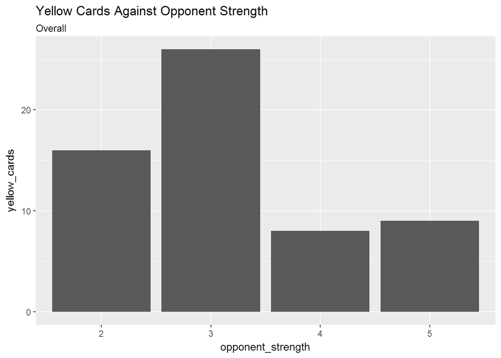

```r
## Yellow Cards
p = ggplot(df_history) +
  geom_bar(aes(x=opponent_strength, y=yellow_cards), stat="identity") +
  ggtitle("Yellow Cards Against Opponent Strength", subtitle = "Overall")
# ggplot(df_history[df_history$yellow_cards==1,]) + geom_bar(aes(yellow_cards)) + facet_grid(. ~ team_strength)
print(p)
```

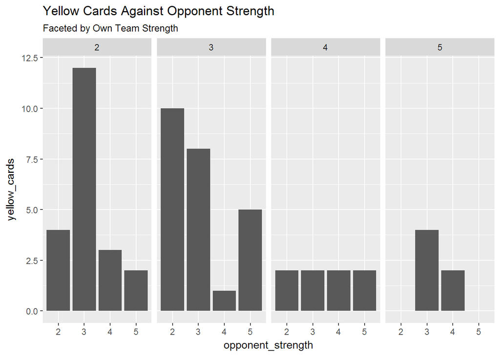

```r
## Yellow Cards. Now let's see if we breakdown by own team strength.
p = p + facet_grid(. ~ team_strength) +
  ggtitle("Yellow Cards Against Opponent Strength", subtitle = "Faceted by Own Team Strength")
print(p)
```

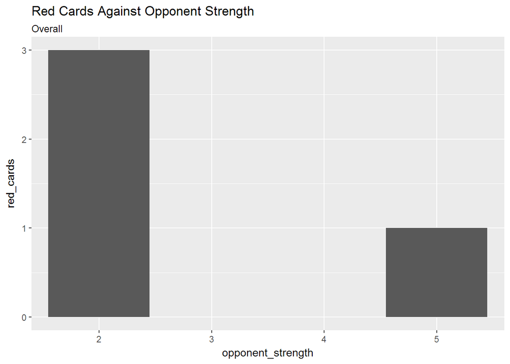

```r
## Yellow Cards
p = ggplot(df_history) +
  geom_bar(aes(x=opponent_strength, y=red_cards), stat="identity") +
  ggtitle("Red Cards Against Opponent Strength", subtitle = "Overall")
print(p)
```

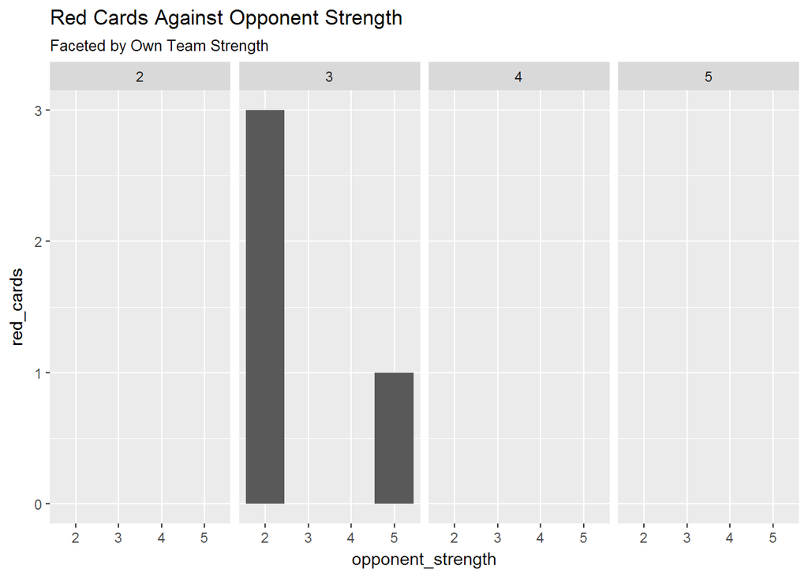

```r
## Yellow Cards. Now let's see if we breakdown by own team strength.
p = p + facet_grid(. ~ team_strength) +
  ggtitle("Red Cards Against Opponent Strength", subtitle = "Faceted by Own Team Strength")
print(p)
```

## Enhanced Optimisation Scoping

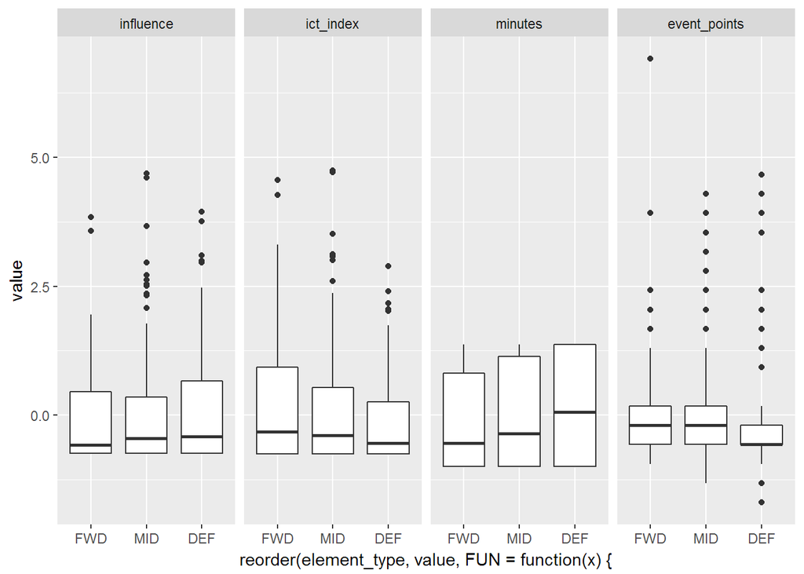

```r
library(ggplot2)
library(reshape2)
df = df_summary[!df_summary$element_type=="GKP",
               c("web_name", "element_type", "influence", "ict_index", "minutes", "event_points")]
df[,-(1:2)] = scale(df[,-(1:2)])
df = melt(df, id.vars=c("web_name", "element_type"))
ggplot(data=df) + geom_boxplot(aes(x=reorder(element_type, value, FUN=function(x){1-mean(x)}), y=value)) +
  facet_grid(. ~ variable, scales="free")
```

## Hindsight Analysis, Could we have done better?

We’ll explore if we tweak a certain parameters, now that we know better about FPL, would it improve our result in hindsight? In this case, the original optimizer weighted the Total Points of full 2017/18 by 37/38 and week01 of 2018/19 by 1/38. Total points are cumulative points, making the original optimizer heavily biased towards 2017/18

We’ll see here, when we normalize the 2017/18 and Week01 2018/19 to be on same weightage total points improve from 43 to 59. Of course, there’s no guarantee this will work again for week02.

```r
library(lpSolveAPI)
library(scales)
library(dplyr)

optimise_base = function(){
  ## Read & merge data from pre-downloaded stats #####################################################
  dfsummary_wk00 = read.csv("./Data/FPL_2018_19_Wk0.csv")
  dfsummary_wk01 = read.csv("./Data/week01_01summary.csv")
  dfsummary_wk02 = read.csv("./Data/week02_01summary.csv")
  # Merge now_cost into week0 player database
  # Mutate ICT_mult, a multiplier/weightage for ICT. Subject to scale 1.00 to 1.15
  player_df = merge(dfsummary_wk00,
                    dfsummary_wk01[,c("web_name","status","now_cost","total_points","element_type")],
                    by.x=c("Name","Position"),
                    by.y=c("web_name", "element_type"),
                    all.y=TRUE)
  player_df = mutate(player_df,
                     ObjPoints = 0.50 * rescale(Points, to=c(0,100)) +
                       0.50 * rescale(total_points, to=c(0,100)))
  player_df = player_df[player_df$status=="a",]   # subset to only non-injured player

  ## Initialise LP model #############################################################################
  # Define decision variables as how to turn on/off (binary) 15 of the 470+ potential players
  decVarNo = nrow(player_df)
  lprec    = make.lp(0, decVarNo)
  lp.control(lprec,sense="max") %>% suppressMessages()
  lprec %>% lp.control(sense="max")
  set.type(lprec, seq(1,decVarNo), type = "binary")

  ## Set LP model objective function #################################################################
  # Objective, by default, is to maximise player modified total points. This can be changed to ICT or
  # other performance/index past few games
  decVar = player_df$ObjPoints
  set.objfn(lprec, decVar)

  ## Set LP model constraints ########################################################################
  # For Base, formation is set for 4-4-2. Hence total team is GKP==2, DEF==5, MID==5 and FWD==3.
  # Total of 15
  add.constraint(lprec, as.numeric(player_df$Position=="GKP"), type="=", 2)
  add.constraint(lprec, as.numeric(player_df$Position=="DEF"), type="=", 5)
  add.constraint(lprec, as.numeric(player_df$Position=="MID"), type="=", 5)
  add.constraint(lprec, as.numeric(player_df$Position=="FWD"), type="=", 3)
  # no more than 3 from the same club
  for (i in unique(player_df$Team)) {
    add.constraint(lprec, as.numeric(player_df$Team==i), type="<=", 3)
  }
  # constraint for cost must be less than 1000 or so. we use current cost of week1.
  add.constraint(lprec, player_df$now_cost, type="<=", rhs=1000)
  # custom constraint as these players are suspects from first iteration, set to 0 to exclude them
  add.constraint(lprec, as.numeric(player_df$Name=="Monreal"), type="=", 0)
  add.constraint(lprec, as.numeric(player_df$Name=="Gross"), type="=", 0)

  ## Solve the LP model ##############################################################################
  solve.lpExtPtr(lprec)

  ## Prep the output data frame ######################################################################
  chosen_ones <- which(get.variables(lprec)==1)   # index (from the 470+ players) of the chosen ones
  chosen_df <- player_df[chosen_ones,]            # subset the main df to only the chosen ones
  chosen_df = arrange(chosen_df, Position, desc(ObjPoints))
  chosen_11s = rbind(head(chosen_df[chosen_df$Position=="GKP",],-1),
                     head(chosen_df[chosen_df$Position=="DEF",],-1),
                     head(chosen_df[chosen_df$Position=="MID",],-1),
                     head(chosen_df[chosen_df$Position=="FWD",],-1))
  ## merge week01 and week02, but only take results from week02
  result_11s = merge(chosen_11s[,c("Name", "Position")],
                     dfsummary_wk02[,c("web_name", "element_type", "event_points")],
                     by.x=c("Name", "Position"),
                     by.y=c("web_name", "element_type"))
}

## Show what we could get
result_11s = optimise_base()
result_11s$Name %>% as.character() %>% print()
```

```
##  [1] "Alonso"     "Ederson"    "Fraser"     "Holebas"    "Pereyra"
##  [6] "Pogba"      "Robertson"  "Salah"      "Vardy"      "Vertonghen"
## [11] "Wilson"
```

```r
paste("The possible event points would be", sum(result_11s$event_points)) %>% print()
```

```
## [1] "The possible event points would be 59"
```